## makeoveR monday 2018

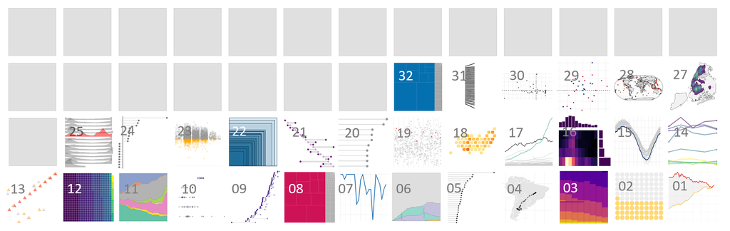

### What is Makeover Monday?

[Makeover Monday](http://makeovermonday.co.uk/) is a weekly data visualization series that allows you to re-work/re-imagine a chart. It is also a good way for me to practice my plotting skills in R. I really like this project, and I can’t believe I didn’t find it sooner (I didn’t get started until week 06, and I’ve since gone back and completed weeks 05 and 04). I don’t know if I’ll be able to, but I’m going to try my best to complete all 52 weeks.

### R

So far I’ve used the ggplot2 package to make all of the plots, but I plan on using base R too. I also want to make some interactive charts and put them on shinyapps.io. I usually get lazy and I don’t do it, but it is one of my goals.

### Visualizations

For each graph below, I include some short comments and the R code needed to make the chart. My code is often not optimal, but you can see (I hope) what my though process was when creating each graph. I probably should customize my own theme for ggplot (I use a lot of the same options in each plot), but I think it’s easier for folks to reproduce the plots if the code can be copied straight from the page.

| Wk | Date | Data Visualization | Topic |
| --- | --- | --- | --- |
| 32 | [Aug 06](https://alexherseg.github.io/makeover_monday/32/2018_08_06.html) | Treemap | Money spent on R&D |
| 31 | [Jul 30](https://alexherseg.github.io/makeover_monday/31/2018_07_30.html) | Slopegraph | Currency Valuation using the Big Mac Index |
| 30 | [Jul 23](https://alexherseg.github.io/makeover_monday/30/2018_07_23.html) | Scatterplot | Maternity Leave in OECD Countries |
| 29 | [Jul 16](https://alexherseg.github.io/makeover_monday/29/2018_07_16.html) | Scatterplot | NBA Team Salaries |
| 28 | [Jul 09](https://alexherseg.github.io/makeover_monday/28/2018_07_09.html) | Map GIF | Volcano Eruptions |
| 27 | [Jul 02](https://alexherseg.github.io/makeover_monday/27/2018_07_02.html) | Contour Plot | Rat Sightings in Ney York City |
| 26 | [Jun 25](https://alexherseg.github.io/makeover_monday/26/2018_06_25.html) | TBD | TBD |
| 25 | [Jun 18](https://alexherseg.github.io/makeover_monday/25/2018_06_18.html) | Joyplot | U.S. Influenza Surveillance Report |
| 24 | [Jun 11](https://alexherseg.github.io/makeover_monday/24/2018_06_11.html) | Lollipop Chart | Tourism Densisty Index |
| 23 | [Jun 04](https://alexherseg.github.io/makeover_monday/23/2018_06_04.html) | Jittered Dot Plot | U.K. Gender Pay Gap |
| 22 | [May 28](https://alexherseg.github.io/makeover_monday/22/2018_05_28.html) | Proportional Symbols Plot | The World’s Most Expensive Prime Property |
| 21 | [May 21](https://alexherseg.github.io/makeover_monday/21/2018_05_21.html) | Range Plot | Premier League Predictions Vs. Reality |
| 20 | [May 14](https://alexherseg.github.io/makeover_monday/20/2018_05_14.html) | Lollipop Chart | European Commuters in Traffic |
| 19 | [May 07](https://alexherseg.github.io/makeover_monday/19/2018_05_07.html) | Jittered Dot Plot | Toughest Sport by Skill |
| 18 | [Apr 30](https://alexherseg.github.io/makeover_monday/18/2018_04_30.html) | Hexagon Grid Map | Bee Colony Loss in the U.S. |
| 17 | [Apr 23](https://alexherseg.github.io/makeover_monday/17/2018_04_23.html) | Time Series | Ecological Footprint Per Capita |
| 16 | [Apr 16](https://alexherseg.github.io/makeover_monday/16/16APR2018.html) | Multiple Plots | Malaria Cases in Zambia’s Southern Province |
| 15 | [Apr 09](https://alexherseg.github.io/makeover_monday/15/09APR2018.html) | Time Series GIF | Artic Sea Ice Extent |
| 14 | [Apr 02](https://alexherseg.github.io/makeover_monday/14/02APR2018.html) | Time Series | World Wine Production |
| 13 | [Mar 26](https://alexherseg.github.io/makeover_monday/13/26MAR2018.html) | Dot Plot | U.K. Chocolate Bar Rankings |
| 12 | [Mar 19](https://alexherseg.github.io/makeover_monday/12_19MAR2018/19MAR2018.html) | Waffle Chart | UK Pet Population |
| 11 | [Mar 12](https://alexherseg.github.io/makeover_monday/11_12MAR2018/12MAR2018.html) | Stacked Area Chart | Irish Whiskey Sales |
| 10 | [Mar 05](https://alexherseg.github.io/makeover_monday/10_05MAR2018/05MAR2018.html) | Dot Plot | International Women’s Day |
| 09 | [Feb 26](https://alexherseg.github.io/makeover_monday/09_26FEB2018/26FEB2018.html) | Range Plot | World Economic Freedom |
| 08 | [Feb 19](https://alexherseg.github.io/makeover_monday/19FEB2018/19FEB2018.html) | Treemap | Where does your medicine come from? |
| 07 | [Feb 12](https://alexherseg.github.io/makeover_monday/12FEB2018/12FEB2018.html) | Bump Chart | Winter Olympics |
| 06 | [Feb 05](https://alexherseg.github.io/makeover_monday/05FEB2018/05FEB2018.html) | Area Bump Chart | Baseball Demographics |
| 05 | [Jan 29](https://alexherseg.github.io/makeover_monday/05_29JAN2018/29JAN2018.html) | Dot Plot | What do the most profitable companies make per second? |
| 04 | [Jan 22](https://alexherseg.github.io/makeover_monday/04_22JAN2018/22JAN2018.html) | Dot Map | Turkey Vulture Migration in South America |
| 03 | [Jan 15](https://alexherseg.github.io/makeover_monday/03/15JAN2018.html) | Heatmap | U.S. Household Income Distribution by State |
| 02 | [Jan 08](https://alexherseg.github.io/makeover_monday/02/08JAN2018.html) | Square Pie Chart | Which Personality Trait Is Most Important in Romantic Partner? |
| 01 | [Jan 01](https://alexherseg.github.io/makeover_monday/01/01JAN2018.html) | Line Chart | U.S. Consumption of Livestock and Poultry |